# Reproducible Data Analysis: project 1

## Loading the data

- Load the data

```r
# path<-"~/proj1"
# setwd(path)
#dir()  #to check data file is present in the same directory or not.
if(!"activity" %in% ls())
    activity<-read.csv("activity.csv")

#understanding data
# names(activity)
# [1] "steps"    "date"     "interval" , interval fro 0 to 2355 for a given day
```

- Process/transform the data (if necessary) into a format suitable for your analysis

```r
stepsPerDay<-aggregate(steps~date,data=activity,sum,na.rm=TRUE)
```

## Q. What is mean total number of steps taken per day?

- Make a histogram of the total number of steps taken each day

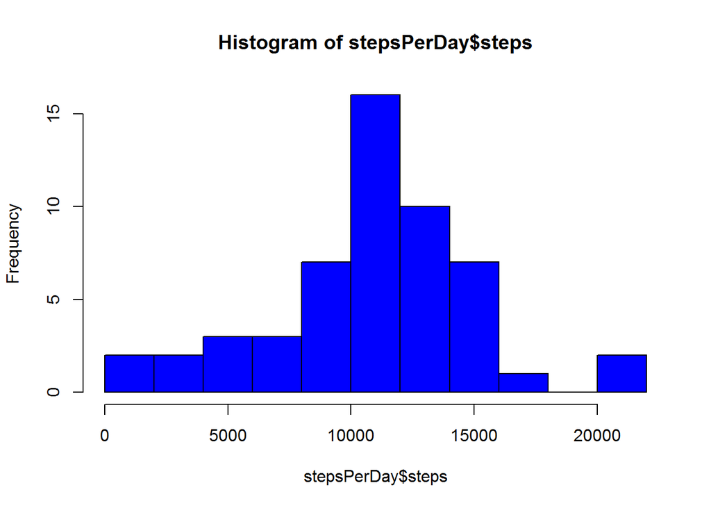

```r
hist(stepsPerDay$steps, breaks = 15, col="blue")
```

- Calculate and report the **mean** and **median** total number of steps taken per day

```r
mean(stepsPerDay$steps)
```

```
## [1] 10766.19
```

```r
median(stepsPerDay$steps)
```

```
## [1] 10765
```

## Q. What is the average daily activity pattern?

- Make a time series plot (i.e. type = “l”) of the 5-minute interval (x-axis) and the average number of steps taken, averaged across all days (y-axis)

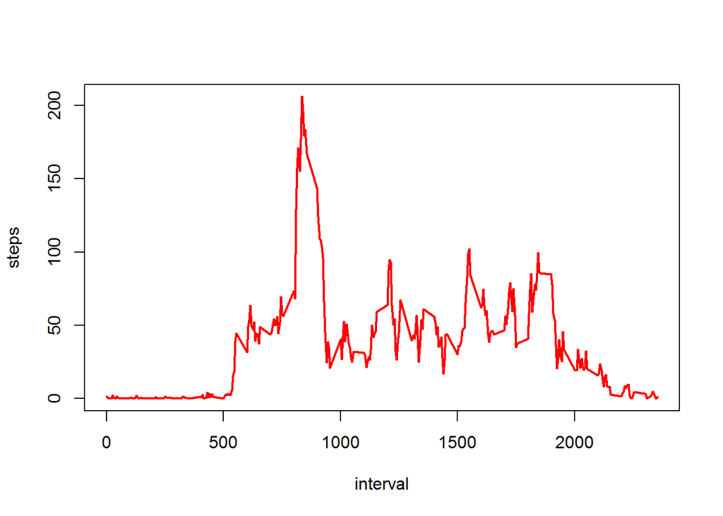

```r
Avg_steps_PerInterval<-aggregate(steps~interval,data=activity,mean,na.rm=TRUE)
plot(Avg_steps_PerInterval,type='l',lwd=2,col="red")
```

- Which 5-minute interval, on average across all the days in the dataset, contains the maximum number of steps?

```r
Avg_steps_PerInterval[which.max(Avg_steps_PerInterval$steps),]$interval
```

```
## [1] 835
```

## Q. Imputing missing values and how they changes results

- Calculate and report the total number of missing values in the dataset (i.e. the total number of rows with NAs)

```r
sum(!complete.cases(activity))
```

```
## [1] 2304
```

Total 2304 rows are missing with a value NA.

- Devise a strategy for filling in all of the missing values in the dataset. The strategy does not need to be sophisticated. For example, you could use the mean/median for that day, or the mean for that 5-minute interval, etc.

: Strategy I adopted here, for filing in all of the missing values with the mean for that 5-minute interval. First of all, I coded a function **“filling”** to get the mean steps for particular 5-minute interval.

```r
filling<-function(interval){
    Avg_steps_PerInterval[Avg_steps_PerInterval$interval==interval,]$steps
}
```

- Create a new dataset that is equal to the original dataset but with the missing data filled in.

```r
activityFilled<-activity   # Make a new dataset with the original data
for(i in 1:nrow(activityFilled)){
    if(is.na(activityFilled[i,]$steps)){
        activityFilled[i,]$steps<-filling(activityFilled[i,]$interval)
    }
}
#sum(is.na(activityFilled))  # returns 0, as a check that no more missing values.
```

- Make a histogram of the total number of steps taken each day and Calculate and report the mean and median total number of steps taken per day.

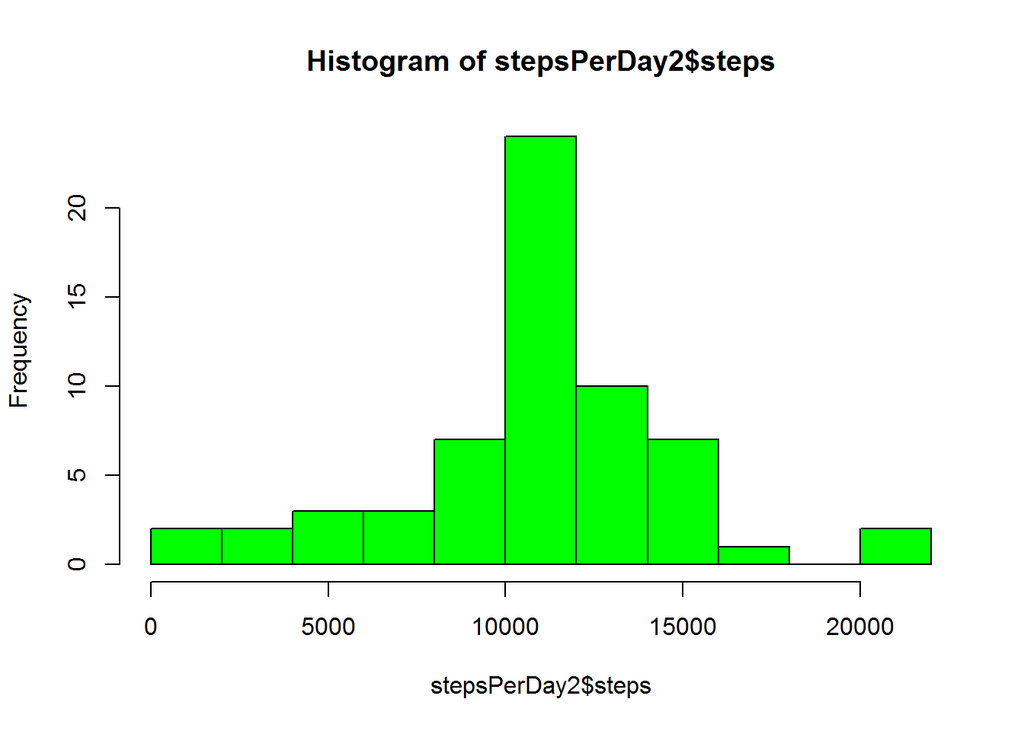

```r
stepsPerDay2<-aggregate(steps~date,data=activityFilled,sum,na.rm=TRUE)
hist(stepsPerDay2$steps, breaks = 15, col="green")
```

```r
mean(stepsPerDay2$steps)
```

```
## [1] 10766.19
```

```r
median(stepsPerDay2$steps)
```

```
## [1] 10766.19
```

: The **mean** value is the **same** as the value before imputing missing data because we put the mean value for that particular 5-min interval. This is why **mean** is unchanged. The median value shows **a little** difference : but it depends on **location of missing values in data set, particularly which day, which interval is missing.**.

## Q. Are there differences in activity patterns between weekdays and weekends?

```r
activityFilled$day=ifelse(as.POSIXlt(as.Date(activityFilled$date))$wday%%6==0,
                          "weekend","weekday")
# For Sunday and Saturday : weekend, Other days : weekday
activityFilled$day=factor(activityFilled$day,levels=c("weekday","weekend"))
```

- Make a panel plot containing a time series plot (i.e. type = “l”) of the 5-minute interval (x-axis) and the average number of steps taken, averaged across all weekday days or weekend days (y-axis). The plot should look something like the following, which was creating using simulated data:

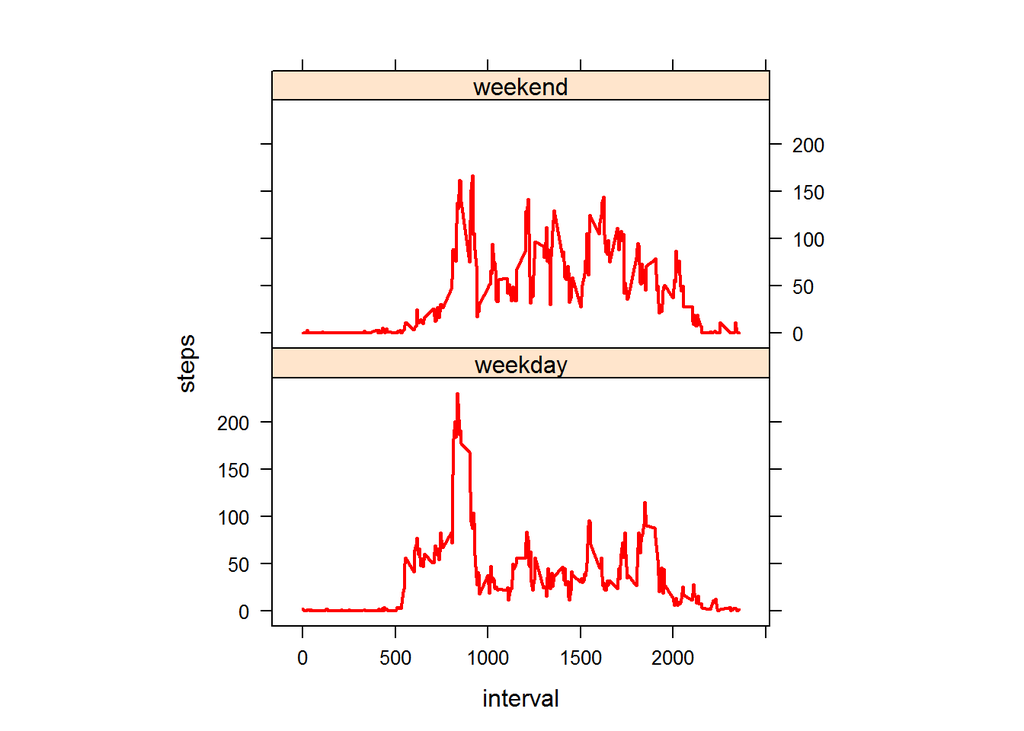

```r
stepsInterval2=aggregate(steps~interval+day,activityFilled,mean)
library(lattice)
xyplot(steps~interval|factor(day),data=stepsInterval2,aspect=1/2,type="l",lwd=2, col="red")
```